# Amazon DataSet

Benard Omido

2023-11-23

# Data Cleaning and Analysis of Amazon Data

### Understanding the Data set

Amazon is an American Tech Multi-National Company whose business interests include E-commerce, where they buy and store the inventory, and take care of everything from shipping and pricing to customer service and returns. This data set contains data of more than 1K Amazon’s products, ratings, reviews, etc.

#### **Primary Objective**

The goal of this project is to clean and transform this Amazon data set into an easy to use format, perform

EDA, and also to derive meaningful insights from it.

Load the necessary libraries

```r
library(tidyverse)
library(readxl)
library(readr)
```

Import the dataset

```r
amazon <- read_csv("F:\\Tutorials\\R tutorials\\Datasets\\amazon.csv")
head(amazon)
```

```
## # A tibble: 6 x 16
##   product_id product_name                 category discounted_price actual_price
##   <chr>      <chr>                        <chr>    <chr>            <chr>
## 1 B07JW9H4J1 Wayona Nylon Braided USB to~ Compute~ ₹399             ₹1,099
## 2 B098NS6PVG Ambrane Unbreakable 60W / 3~ Compute~ ₹199             ₹349
## 3 B096MSW6CT Sounce Fast Phone Charging ~ Compute~ ₹199             ₹1,899
## 4 B08HDJ86NZ boAt Deuce USB 300 2 in 1 T~ Compute~ ₹329             ₹699
## 5 B08CF3B7N1 Portronics Konnect L 1.2M F~ Compute~ ₹154             ₹399
## 6 B08Y1TFSP6 pTron Solero TB301 3A Type-~ Compute~ ₹149             ₹1,000
## # i 11 more variables: discount_percentage <chr>, rating <dbl>,
## #   rating_count <dbl>, about_product <chr>, user_id <chr>, user_name <chr>,
## #   review_id <chr>, review_title <chr>, review_content <chr>, img_link <chr>,
## #   product_link <chr>
```

Check the data types and structure of variables

```r
glimpse(amazon)
```

```
## Rows: 1,465
## Columns: 16
## $ product_id          <chr> "B07JW9H4J1", "B098NS6PVG", "B096MSW6CT", "B08HDJ8~
## $ product_name        <chr> "Wayona Nylon Braided USB to Lightning Fast Chargi~
## $ category            <chr> "Computers&Accessories|Accessories&Peripherals|Cab~
## $ discounted_price    <chr> "\u20b9399", "\u20b9199", "\u20b9199", "\u20b9329"~
## $ actual_price        <chr> "\u20b91,099", "\u20b9349", "\u20b91,899", "\u20b9~
## $ discount_percentage <chr> "64%", "43%", "90%", "53%", "61%", "85%", "65%", "~
## $ rating              <dbl> 4.2, 4.0, 3.9, 4.2, 4.2, 3.9, 4.1, 4.3, 4.0, 4.3, ~
## $ rating_count        <dbl> 24269, 43994, 7928, 94363, 16905, 24871, 15188, 30~
## $ about_product       <chr> "High Compatibility : Compatible With iPhone 12, 1~
## $ user_id             <chr> "AG3D6O4STAQKAY2UVGEUV46KN35Q,AHMY5CWJMMK5BJRBBSNL~
## $ user_name           <chr> "Manav,Adarsh gupta,Sundeep,S.Sayeed Ahmed,jaspree~
## $ review_id           <chr> "R3HXWT0LRP0NMF,R2AJM3LFTLZHFO,R6AQJGUP6P86,R1KD19~
## $ review_title        <chr> "Satisfied,Charging is really fast,Value for money~
## $ review_content      <chr> "Looks durable Charging is fine tooNo complains,Ch~
## $ img_link            <chr> "https://m.media-amazon.com/images/W/WEBP_402378-T~
## $ product_link        <chr> "https://www.amazon.in/Wayona-Braided-WN3LG1-Synci~
```

Check for null values, and duplicates

```r
#Use skimr to check for null values
skimr::skim(amazon)
```

Data summary

| Name | amazon |
| --- | --- |
| Number of rows | 1465 |
| Number of columns | 16 |
| _______________________ |  |
| Column type frequency: |  |
| character | 14 |
| numeric | 2 |
| ________________________ |  |
| Group variables | None |

**Variable type: character**

| skim_variable | n_missing | complete_rate | min | max | empty | n_unique | whitespace |
| --- | --- | --- | --- | --- | --- | --- | --- |
| product_id | 0 | 1 | 10 | 10 | 0 | 1351 | 0 |
| product_name | 0 | 1 | 16 | 485 | 0 | 1337 | 0 |
| category | 0 | 1 | 29 | 119 | 0 | 211 | 0 |
| discounted_price | 0 | 1 | 3 | 9 | 0 | 550 | 0 |
| actual_price | 0 | 1 | 3 | 9 | 0 | 449 | 0 |
| discount_percentage | 0 | 1 | 2 | 3 | 0 | 92 | 0 |
| about_product | 0 | 1 | 5 | 2646 | 0 | 1293 | 0 |
| user_id | 0 | 1 | 28 | 231 | 0 | 1194 | 0 |
| user_name | 0 | 1 | 6 | 137 | 0 | 1194 | 0 |
| review_id | 0 | 1 | 12 | 119 | 0 | 1194 | 0 |
| review_title | 0 | 1 | 7 | 407 | 0 | 1194 | 0 |
| review_content | 0 | 1 | 67 | 18547 | 0 | 1212 | 0 |
| img_link | 0 | 1 | 65 | 114 | 0 | 1412 | 0 |
| product_link | 0 | 1 | 101 | 188 | 0 | 1465 | 0 |

**Variable type: numeric**

| skim_variable | n_missing | complete_rate | mean | sd | p0 | p25 | p50 | p75 | p100 | hist |
| --- | --- | --- | --- | --- | --- | --- | --- | --- | --- | --- |
| rating | 1 | 1 | 4.10 | 0.29 | 2 | 4 | 4.1 | 4.3 | 5 | ▁▁▂▇▁ |
| rating_count | 2 | 1 | 18295.54 | 42753.86 | 2 | 1186 | 5179.0 | 17336.5 | 426973 | ▇▁▁▁▁ |

```r
#Identify and count duplicates
amazon %>%
  summarize(total_dups <- sum(duplicated(.)))
```

```
## # A tibble: 1 x 1
##   `total_dups <- sum(duplicated(.))`
##                                <int>
## 1                                  0
```

There appears to be one null value in the rating column, and two in the rating_count column, but there are no duplicates

### **Data Cleaning Tasks**

1. Create a new data frame that contains columns to be used for analysis
2. Convert discounted_price, actual_price, and discounted_percentage to numeric form
3. Fill in missing values
4. Split the category column

**1.Create a new data frame**

```r
df <- amazon %>%
  select(-c(img_link, product_link, about_product, user_id, user_name, review_id, review_title, review_content))

View(df)
```

**2. Changing data types**

```r
#Strip the (₹ and ,) in discounted_price and actual_price, then convert to numeric

df <- df %>%
  mutate(
    across(
      contains("price"),
      .fns = ~as.numeric(str_replace_all(.x, "[^0-9.]", ""))
    )
  )

head(df)
```

```
## # A tibble: 6 x 8
##   product_id product_name                 category discounted_price actual_price
##   <chr>      <chr>                        <chr>               <dbl>        <dbl>
## 1 B07JW9H4J1 Wayona Nylon Braided USB to~ Compute~              399         1099
## 2 B098NS6PVG Ambrane Unbreakable 60W / 3~ Compute~              199          349
## 3 B096MSW6CT Sounce Fast Phone Charging ~ Compute~              199         1899
## 4 B08HDJ86NZ boAt Deuce USB 300 2 in 1 T~ Compute~              329          699
## 5 B08CF3B7N1 Portronics Konnect L 1.2M F~ Compute~              154          399
## 6 B08Y1TFSP6 pTron Solero TB301 3A Type-~ Compute~              149         1000
## # i 3 more variables: discount_percentage <chr>, rating <dbl>,
## #   rating_count <dbl>
```

```r
#Transform the discount_percentage column
class(df$discount_percentage)
```

```
## [1] "character"
```

```r
df$discount_percentage <- as.numeric(str_replace_all(df$discount_percentage, "%", "")) / 100
```

**3. Fill in missing values**

```r
df %>%
  filter(is.na(rating))
```

```
## # A tibble: 1 x 8
##   product_id product_name                 category discounted_price actual_price
##   <chr>      <chr>                        <chr>               <dbl>        <dbl>
## 1 B08L12N5H1 Eureka Forbes car Vac 100 W~ Home&Ki~             2099         2499
## # i 3 more variables: discount_percentage <dbl>, rating <dbl>,
## #   rating_count <dbl>
```

```r
#After investigating this null value in the amazon products website, the correct rating for this product ID should be 4
class(df$rating)
```

```
## [1] "numeric"
```

```r
df$rating <- if_else(is.na(df$rating), as.numeric(4), df$rating)
```

**4. Split the category column**

```r
df <- df %>%
  separate(category, into = c("MainCategory", "SubCategory"), sep = "\\|")

head(df)
```

```
## # A tibble: 6 x 9
##   product_id product_name MainCategory SubCategory discounted_price actual_price
##   <chr>      <chr>        <chr>        <chr>                  <dbl>        <dbl>
## 1 B07JW9H4J1 Wayona Nylo~ Computers&A~ Accessorie~              399         1099
## 2 B098NS6PVG Ambrane Unb~ Computers&A~ Accessorie~              199          349
## 3 B096MSW6CT Sounce Fast~ Computers&A~ Accessorie~              199         1899
## 4 B08HDJ86NZ boAt Deuce ~ Computers&A~ Accessorie~              329          699
## 5 B08CF3B7N1 Portronics ~ Computers&A~ Accessorie~              154          399
## 6 B08Y1TFSP6 pTron Soler~ Computers&A~ Accessorie~              149         1000
## # i 3 more variables: discount_percentage <dbl>, rating <dbl>,
## #   rating_count <dbl>
```

Check the unique values in both the MainCategory and SubCategory

```r
df %>%
  count(MainCategory)
```

```
## # A tibble: 9 x 2
##   MainCategory              n
##   <chr>                 <int>
## 1 Car&Motorbike             1
## 2 Computers&Accessories   453
## 3 Electronics             526
## 4 Health&PersonalCare       1
## 5 Home&Kitchen            448
## 6 HomeImprovement           2
## 7 MusicalInstruments        2
## 8 OfficeProducts           31
## 9 Toys&Games                1
```

Fix the strings in the Main Category, for easy readability

```r
df <- df %>%
  mutate(
    across(
      MainCategory,
      .fns = ~str_replace_all(.x, c("&"=" ", "MusicalInstruments"="Musical Instruments",
                                    "OfficeProducts"="Office Products", "HomeImprovement"="Home Improvement")
    )
  ))

unique(df$MainCategory)
```

```
## [1] "Computers Accessories" "Electronics"           "Musical Instruments"
## [4] "Office Products"       "Home Kitchen"          "Home Improvement"
## [7] "Toys Games"            "Car Motorbike"         "Health PersonalCare"
```

Fix the strings in Sub Category Column

```r
df %>%
  count(SubCategory)
```

```
## # A tibble: 29 x 2
##    SubCategory                                 n
##    <chr>                                   <int>
##  1 Accessories                                14
##  2 Accessories&Peripherals                   381
##  3 Arts&Crafts                                 1
##  4 Cameras&Photography                        16
##  5 CarAccessories                              1
##  6 Components                                  5
##  7 CraftMaterials                              7
##  8 Electrical                                  2
##  9 ExternalDevices&DataStorage                18
## 10 GeneralPurposeBatteries&BatteryChargers    14
## # i 19 more rows
```

```r
df <- df %>%
  mutate(
    across(
      SubCategory,
      .fns =  ~str_replace_all(.x, c("&"=" ", "NetworkingDevices"="Networking Devices",
                                     "HomeTheater"="Home Theater", "HomeAudio"="Home Audio",    "WearableTechnology"="Wearble Technology",
                                     "ExternalDevices"="External Devices", "GeneralPurposeBatteries"="General Purpose Batteries",
                                     "OfficePaperProducts" = "Office Paper Products", "CraftMaterials"="Craft Materials",
                                     "OfficeElectronics"="Office Electronics", "PowerAccessories"="Power Accessories",
                                     "HomeStorage"="Home Storage", "HomeMedicalSupplies"="Home Medical Supplies",
                                     "CarAccessories"="Car Accessories", "HomeAppliances"="Home Appliances"))
    )
  )

unique(df$SubCategory)
```

```
##  [1] "Accessories Peripherals"
##  [2] "Home Theater,TV Video"
##  [3] "Networking Devices"
##  [4] "Wearble Technology"
##  [5] "Accessories"
##  [6] "Headphones,Earbuds Accessories"
##  [7] "Mobiles Accessories"
##  [8] "Home Audio"
##  [9] "External Devices DataStorage"
## [10] "Microphones"
## [11] "General Purpose Batteries BatteryChargers"
## [12] "Office Paper Products"
## [13] "Craft Materials"
## [14] "Cameras Photography"
## [15] "Office Electronics"
## [16] "Printers,Inks Accessories"
## [17] "Monitors"
## [18] "Components"
## [19] "Electrical"
## [20] "Arts Crafts"
## [21] "Power Accessories"
## [22] "Tablets"
## [23] "Laptops"
## [24] "Kitchen Home Appliances"
## [25] "Heating,Cooling AirQuality"
## [26] "Kitchen Dining"
## [27] "Home Storage Organization"
## [28] "Car Accessories"
## [29] "Home Medical Supplies Equipment"
```

### **Exploratory Data Analysis**

**1. Table Displaying Distribution of Products By Main Category and Sub Category**

```r
library(knitr)
library(kableExtra)

k <- df %>%
  group_by(MainCategory, SubCategory) %>%
  summarize(n = n())

k %>%
  kable(digits = 0, format = "html", caption = "Number Of Products Per Main Category and Sub Category") %>%
  kable_classic("striped", "bordered", full_width = FALSE, html_font = "Cambria",
                position = "left") %>%
  add_header_above(c(" "=2, "Product Count")) %>%
  row_spec(0, bold = TRUE) %>%
  column_spec(1, bold = TRUE, color = "white", background = "#CD661D")
```

Number Of Products Per Main Category and Sub Category

| MainCategory | SubCategory | Product Count n |
| --- | --- | --- |
| Car Motorbike | Car Accessories | 1 |
| Computers Accessories | Accessories Peripherals | 381 |
| Computers Accessories | Components | 5 |
| Computers Accessories | External Devices DataStorage | 18 |
| Computers Accessories | Laptops | 1 |
| Computers Accessories | Monitors | 2 |
| Computers Accessories | Networking Devices | 34 |
| Computers Accessories | Printers,Inks Accessories | 11 |
| Computers Accessories | Tablets | 1 |
| Electronics | Accessories | 14 |
| Electronics | Cameras Photography | 16 |
| Electronics | General Purpose Batteries BatteryChargers | 14 |
| Electronics | Headphones,Earbuds Accessories | 66 |
| Electronics | Home Audio | 16 |
| Electronics | Home Theater,TV Video | 162 |
| Electronics | Mobiles Accessories | 161 |
| Electronics | Power Accessories | 1 |
| Electronics | Wearble Technology | 76 |
| Health PersonalCare | Home Medical Supplies Equipment | 1 |
| Home Improvement | Electrical | 2 |
| Home Kitchen | Craft Materials | 7 |
| Home Kitchen | Heating,Cooling AirQuality | 116 |
| Home Kitchen | Home Storage Organization | 16 |
| Home Kitchen | Kitchen Dining | 1 |
| Home Kitchen | Kitchen Home Appliances | 308 |
| Musical Instruments | Microphones | 2 |
| Office Products | Office Electronics | 4 |
| Office Products | Office Paper Products | 27 |
| Toys Games | Arts Crafts | 1 |

**2. Bar plots displaying the number of products by the Main Category and Sub Category**

**Main Category**

```r
#Check the number of products under each category

df %>%
  count(MainCategory)
```

```
## # A tibble: 9 x 2
##   MainCategory              n
##   <chr>                 <int>
## 1 Car Motorbike             1
## 2 Computers Accessories   453
## 3 Electronics             526
## 4 Health PersonalCare       1
## 5 Home Improvement          2
## 6 Home Kitchen            448
## 7 Musical Instruments       2
## 8 Office Products          31
## 9 Toys Games                1
```

Five of the products in the MainCategory had a count of less than or equal to 2, thus for easier visualization, I combined the smaller products and assigned them to “Other”

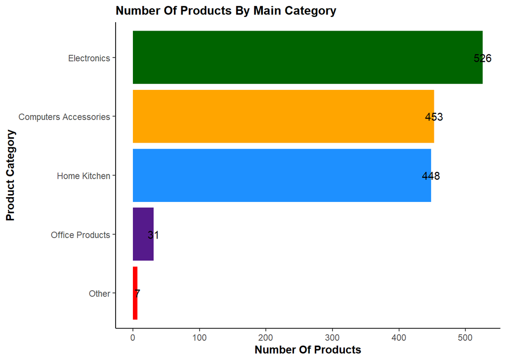

```r
p <- df %>%
  mutate(MainCategory = fct_collapse(MainCategory,
                                     Other = c("Car Motorbike", "Health PersonalCare", "Home Improvement", "Musical Instruments", "Toys Games")))


#Use fct_rev() and fct_infreq() to reorder the categories using frequency

p_main <- ggplot(p, aes(fct_rev(fct_infreq(MainCategory)))) +
  geom_bar(aes(fill = MainCategory)) +
  coord_flip() +
  scale_fill_manual(values = c("red", "orange", "darkgreen", "dodgerblue", "purple4")) +
  labs(title = "Number Of Products By Main Category",
       y = "Number Of Products",
       x = "Product Category") +
  geom_text(stat = "count", aes(label = after_stat(count)), vjust = 0.5) +
  theme_classic() +
  theme(legend.position = "none",
        axis.title = element_text(face = "bold"),
        plot.title = element_text(face = "bold", size = 12))

p_main
```

**Sub Category**

```r
#Check the number of products in each sub category
df %>%
  count(SubCategory, sort = TRUE)
```

```
## # A tibble: 29 x 2
##    SubCategory                        n
##    <chr>                          <int>
##  1 Accessories Peripherals          381
##  2 Kitchen Home Appliances          308
##  3 Home Theater,TV Video            162
##  4 Mobiles Accessories              161
##  5 Heating,Cooling AirQuality       116
##  6 Wearble Technology                76
##  7 Headphones,Earbuds Accessories    66
##  8 Networking Devices                34
##  9 Office Paper Products             27
## 10 External Devices DataStorage      18
## # i 19 more rows
```

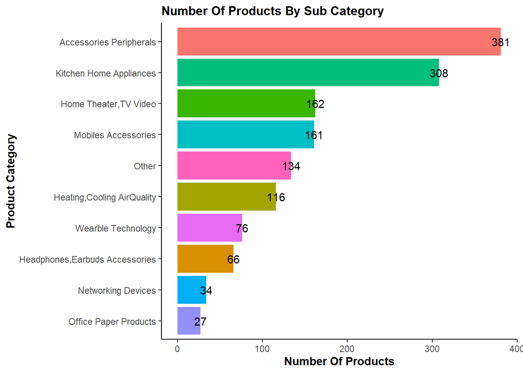

```r
#There are 29 subcategories, for easy visualization, I used fct_lump() to combine together all sub categories # with count less than 20

p1 <- df %>%
  mutate(SubCategory = fct_lump(SubCategory, n = 9))


p_sub <- ggplot(p1, aes(fct_rev(fct_infreq(SubCategory)))) +
  geom_bar(aes(fill = SubCategory)) +
  coord_flip() +
  labs(title = "Number Of Products By Sub Category",
       y = "Number Of Products",
       x = "Product Category") +
  geom_text(stat = "count", aes(label = after_stat(count)), vjust = 0.5) +
  theme_classic() +
  theme(axis.title = element_text(face = "bold"),
        plot.title = element_text(face = "bold", size = 12),
        legend.position = "none")

p_sub
```

Combine the two plots for easy comparison

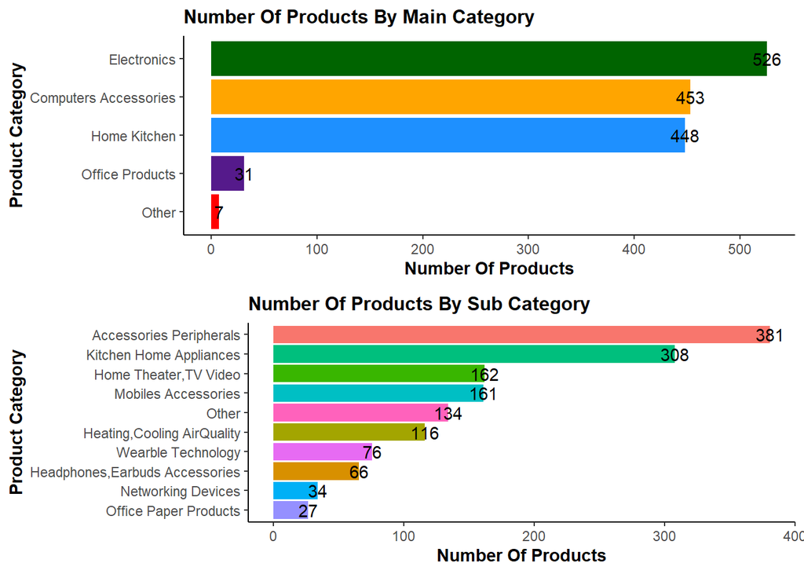

```r
#Load cowplot() library
library(cowplot)

plot_grid(p_main, p_sub, ncol = 1)
```

**Insights**

Under the main category, Electronics had the highest number of sales, followed closely by Computer Accessories, while in the Sub category, Accessories and Peripherals had the highest sales, thus in conclusion, electronics and computer accessories were the best performing products in terms of sales.

**3. Check whether there exists a relationship between discounted price and actual price**

```r
class(df$discounted_price)
```

```
## [1] "numeric"
```

```r
class(df$actual_price)
```

```
## [1] "numeric"
```

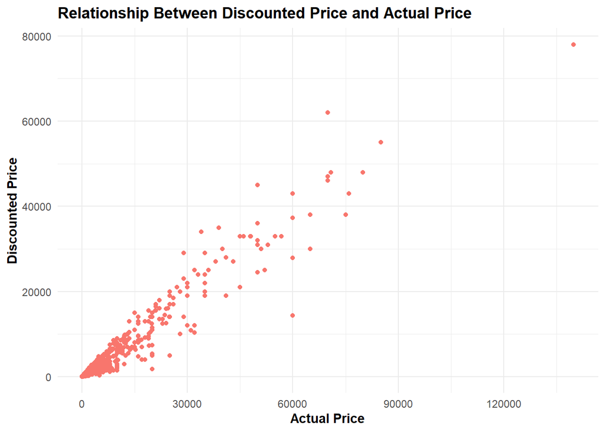

```r
ggplot(df, aes(actual_price, discounted_price)) +
  geom_point(aes(color = "dodgerblue")) +
  scale_x_continuous(breaks = seq(0, 150000, 30000)) +
  labs(title = "Relationship Between Discounted Price and Actual Price",
       x = "Actual Price",
       y = "Discounted Price") +
  theme_minimal() +
  theme(legend.position = "none",
        axis.title = element_text(color = "black", face = "bold"),
        plot.title = element_text(face = "bold"))
```

```r
cor.test(df$discounted_price, df$actual_price)
```

```
##
##  Pearson's product-moment correlation
##
## data:  df$discounted_price and df$actual_price
## t = 134.6, df = 1463, p-value < 2.2e-16
## alternative hypothesis: true correlation is not equal to 0
## 95 percent confidence interval:
##  0.9578903 0.9655623
## sample estimates:
##       cor
## 0.9619153
```

**Insights**

Discounted price and Actual price are highly correlated, with a correlation coefficient of 0.9619153, which indicates a strong positive relationship. Thus, as the actual price of products increases, the amount of discount given also increases.

**4. Exploring the distribution of Rating and Rating Count Across all Products**

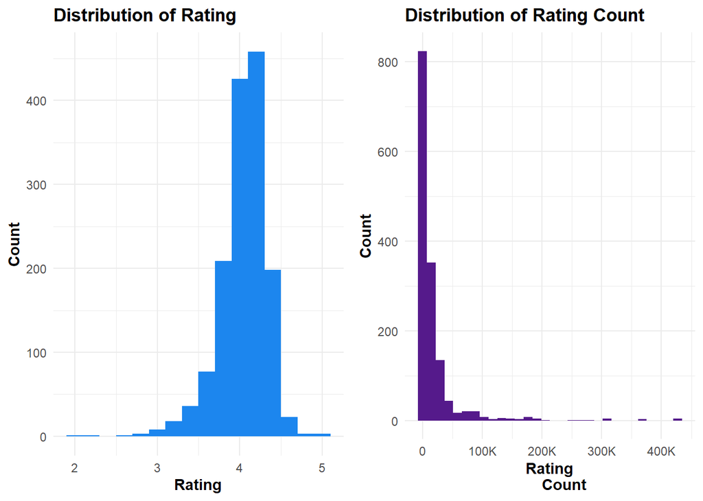

```r
x1 <- ggplot(df, aes(rating)) +
  geom_histogram(binwidth = 0.2, aes(fill = c("#1C86EE"))) +
  scale_fill_manual(values = c("#1C86EE")) +
  labs(x = "Rating",
       y = "Count",
       title = "Distribution of Rating") +
  theme_minimal() +
  theme(legend.position = "none",
        axis.title = element_text(face = "bold"),
        plot.title = element_text(face = "bold"))


x2 <- ggplot(df, aes(rating_count)) +
  geom_histogram(aes(fill = "purple4")) +
  scale_fill_manual(values = c("purple4")) +
  labs(x = "Rating
       Count",
       y = "Count",
       title = "Distribution of Rating Count") +
  theme_minimal() +
  theme(legend.position = "none",
        axis.title = element_text(face = "bold"),
        plot.title = element_text(face = "bold")) +
  scale_x_continuous(breaks = seq(0, 500000, 100000),
                     labels = c(0, "100K", "200K", "300K", "400K", "500K"))


plot_grid(x1, x2, ncol = 2)
```

**Insights**

The rating distribution is Left skewed, while the amount of Ratings given to a product distribution is Right skewed. Most of the products have a rating of between 3.9 - 4.3, majority have been rated less than 10,000 times, while there are a few exceptional ones which have been rated more than 100,000 times.

**5. The Distribution of Rating under different Product Categories**

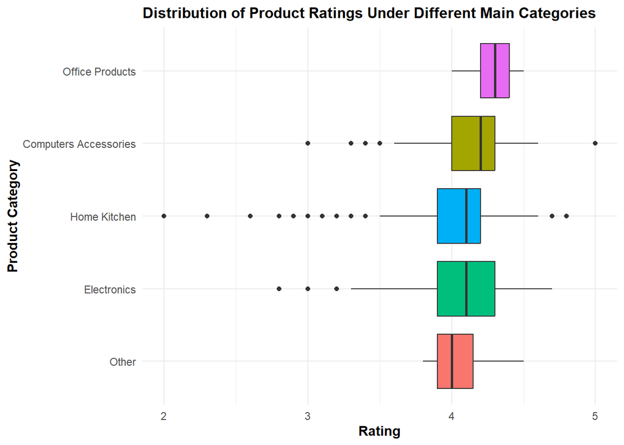

```r
#Since the mainCategory column contains categories with count less than 10, I combined some categories, just like how I had done initially, for easy visualization and comparison making

df %>%
  mutate(MainCategory = fct_collapse(MainCategory,
                                     Other = c("Car Motorbike", "Health PersonalCare", "Home Improvement", "Musical Instruments", "Toys Games"))) %>%
  ggplot(aes(fct_reorder(MainCategory, rating), rating)) +
  geom_boxplot(aes(fill = MainCategory)) +
  coord_flip() +
  labs(title = "Distribution of Product Ratings Under Different Main Categories",
       x = "Product Category",
       y = "Rating") +
  theme_minimal() +
  theme(plot.title = element_text(face = "bold", size = 12),
        axis.title = element_text(face = "bold"),
        legend.position = "none")
```

**Insights**

Office Products had the highest median ratings of approximately 4.3, followed by Computer Accessories. Notably, the home kitchen category had a number of low ratings, with the lowest being 2.0.

**6. Cut the ratings column into satisfaction levels to determine the overall customer’s satisfaction for all products**

```r
df_rating <- df %>%
  mutate(
    rating_score = cut(rating,
                    breaks = 3,
                    labels = c("Unsatisfied", "Satisfied", "Very Satisfied"))
  ) %>%
  group_by(rating_score) %>%
  summarize(score_count = n()) %>%
  ungroup() %>%
  mutate(percent = score_count / sum(score_count))


df_rating
```

```
## # A tibble: 3 x 3
##   rating_score   score_count percent
##   <fct>                <int>   <dbl>
## 1 Unsatisfied             10 0.00683
## 2 Satisfied              526 0.359
## 3 Very Satisfied         929 0.634
```

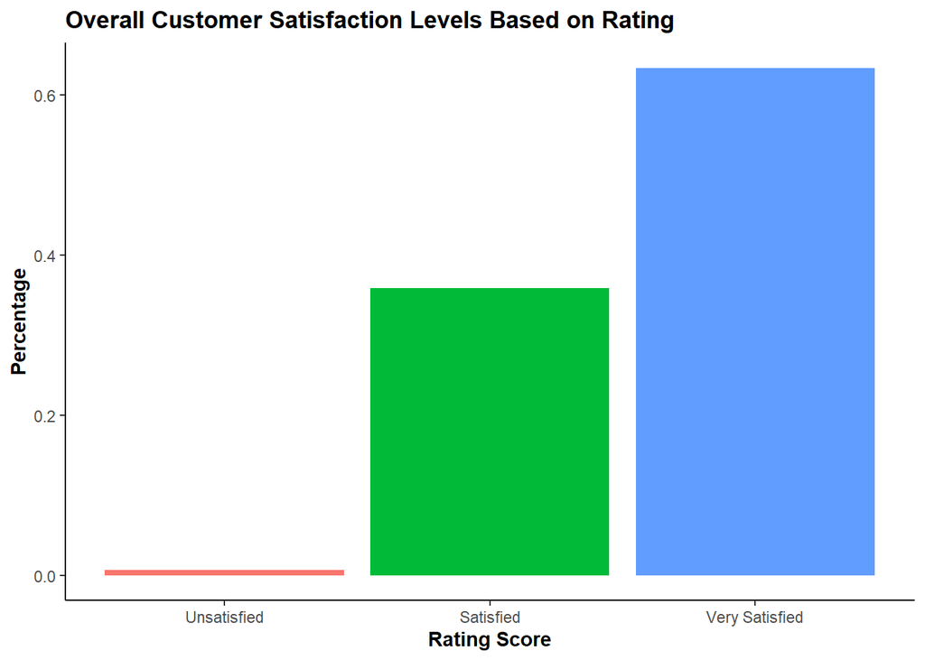

```r
ggplot(df_rating, aes(rating_score, percent)) +
  geom_col(aes(fill = rating_score)) +
  labs(title = "Overall Customer Satisfaction Levels Based on Rating",
       x = "Rating Score",
       y = "Percentage") +
  theme_classic() +
  theme(legend.position = "none",
        axis.title = element_text(face = "bold"),
        plot.title = element_text(face = "bold"))
```

**Insights**

63% of the customers were “Very Satisfied” by the products in this data set, where as 0.6% were “Unsatisfied”.

## **Limitations**

While these insights offer valuable guidance to Amazon customers, it is important to note that this analysis had its own short comings, which include:

1. Products Consolidation: In the analysis, I consolidated categories that had small sizes to enable easy comparison of different product performances, this may have introduced potential bias.
2. Outdated data: The data set was recorded 10 months ago, there might have been changes in the quantity of products across this period. This time difference may affect relevance and applicability of the findings.